# Práctica 2

Guillermo Cadavid, Pau Pous

2025-01-20

## Configuracion

```r
FULL_URL_CONST <- "https://www.mediawiki.org/wiki/MediaWiki/"
BASE_URL_CONST <- "https://www.mediawiki.org/"

# Si TRUE, cargara los datos locales ya descargados y no realizara ninguna peticion a la pagina web para scraping.
USE_CACHE_DATA <- TRUE
```

## Pregunta 1

**1. Descargar la página web de la URL indicada, y almacenarlo en un formato de R apto para ser tratado.**

```r
html <- read_html(BASE_URL_CONST)
```

**2. Analizar el contenido de la web, buscando el título de la página (que en HTML se etiqueta como “title”).**

```r
title <- html %>%
  html_elements("title") %>%
  html_text2()
```

El title es: **MediaWiki**

**3. Analizar el contenido de la web, buscando todos los enlaces (que en HTML se etiquetan como “a”), buscando el texto del enlace, así como la URL.**

```r
a_objects <- html %>% html_elements("a")

raw_links <- data.frame(
  href = a_objects %>% html_attr("href"),
  text = a_objects %>% html_text()
)

head(raw_links)
```

```
##                                           href            text
## 1                                 #bodyContent Jump to content
## 2                              /wiki/MediaWiki       Main page
## 3                               /wiki/Download   Get MediaWiki
## 4 /wiki/Special:MyLanguage/Category:Extensions  Get extensions
## 5              https://techblog.wikimedia.org/       Tech blog
## 6   /wiki/Special:MyLanguage/How_to_contribute      Contribute
```

**4. Generar una tabla con cada enlace encontrado, indicando el texto que acompaña el enlace, y el número de veces que aparece un enlace con ese mismo objetivo.**

**5. Para cada enlace, seguirlo e indicar si está activo (podemos usar el código de status HTTP al hacer una petición a esa URL).**

```r
if (!USE_CACHE_DATA) {
  links <- raw_links %>%
    na.omit() %>%
    count(href, text, name = "freq") %>%
    mutate(is_absoulte = href_is_absolute_v(href)) %>%
    mutate(href_full = parse_href_v(href)) %>%
    rowwise() %>%
    mutate(status = check_link_v(href_full))
  save(links, file = "links.Rda")
}

if (USE_CACHE_DATA) {
load("links.Rda")
}

links %>%
  arrange(desc(freq)) %>%
  select(-is_absoulte, -href_full) %>%
  kbl(
    col.names = c("Enlace", "Texto", "Visto", "Estado"),
    align = "llccc",
  ) %>%
  add_header_above(c("Cabecera" = 1, setNames(3, title))) %>%
  kable_styling(bootstrap_options = c("responsive"))
```

| Cabecera Enlace | MediaWiki Texto | MediaWiki Visto | MediaWiki Estado |
| --- | --- | --- | --- |
| # |  | 7 | 200 |
| /w/index.php?title=MediaWiki&action=edit | View source | 2 | 200 |
| /w/index.php?title=MediaWiki&action=history | View history | 2 | 200 |
| /wiki/MediaWiki | Read | 2 | 200 |
| /wiki/Special:MyLanguage/Manual:FAQ | FAQ | 2 | 200 |
| https://donate.wikimedia.org/?wmf_source=donate&wmf_medium=sidebar&wmf_campaign=www.mediawiki.org&uselang=en | Donate | 2 | 200 |
| # | Add topic | 1 | 200 |
| # | English | 1 | 200 |
| #bodyContent | Jump to content | 1 | 200 |
| //commons.wikimedia.org/wiki/Special:UploadWizard | Upload file | 1 | 404 |
| //m.mediawiki.org/w/index.php?title=MediaWiki&mobileaction=toggle_view_mobile | Mobile view | 1 | 404 |
| /w/index.php?title=MediaWiki&action=info | Page information | 1 | 200 |
| /w/index.php?title=MediaWiki&oldid=6287429 | Permanent link | 1 | 200 |
| /w/index.php?title=MediaWiki&printable=yes | Printable version | 1 | 200 |
| /w/index.php?title=Special:Book&bookcmd=book_creator&referer=MediaWiki | Create a book | 1 | 200 |
| /w/index.php?title=Special:CiteThisPage&page=MediaWiki&id=6287429&wpFormIdentifier=titleform | Cite this page | 1 | 200 |
| /w/index.php?title=Special:CreateAccount&returnto=MediaWiki | Create account | 1 | 200 |
| /w/index.php?title=Special:CreateAccount&returnto=MediaWiki | Create account | 1 | 200 |
| /w/index.php?title=Special:DownloadAsPdf&page=MediaWiki&action=show-download-screen | Download as PDF | 1 | 200 |
| /w/index.php?title=Special:QrCode&url=https%3A%2F%2Fwww.mediawiki.org%2Fwiki%2FMediaWiki | Download QR code | 1 | 200 |
| /w/index.php?title=Special:UrlShortener&url=https%3A%2F%2Fwww.mediawiki.org%2Fwiki%2FMediaWiki | Get shortened URL | 1 | 200 |
| /w/index.php?title=Special:UserLogin&returnto=MediaWiki | Log in | 1 | 200 |
| /w/index.php?title=Special:UserLogin&returnto=MediaWiki | Log in | 1 | 200 |
| /wiki/Category:Languages_pages | Languages pages | 1 | 200 |
| /wiki/Development_statistics | Code statistics | 1 | 200 |
| /wiki/Download | Get MediaWiki | 1 | 200 |
| /wiki/File:Wikimedia_Hackathon_2024_-_Group_photo,_360_cam.jpg |  | 1 | 200 |
| /wiki/Help:Contents |  | 1 | 200 |
| /wiki/Help:Editing_pages |  | 1 | 200 |
| /wiki/Help:Introduction | learn more | 1 | 404 |

[output cut: 146 more lines]

## Pregunta 2

Elaborad, usando las librerías de gráficos base y qplot (ggplot2), una infografía sobre los datos obtenidos. Tal infografía será una reunión de gráficos donde se muestren los siguientes detalles:

**1. Un histograma con la frecuencia de aparición de los enlaces, pero separado por URLs absolutas (con “http…”) y URLs relativas.**

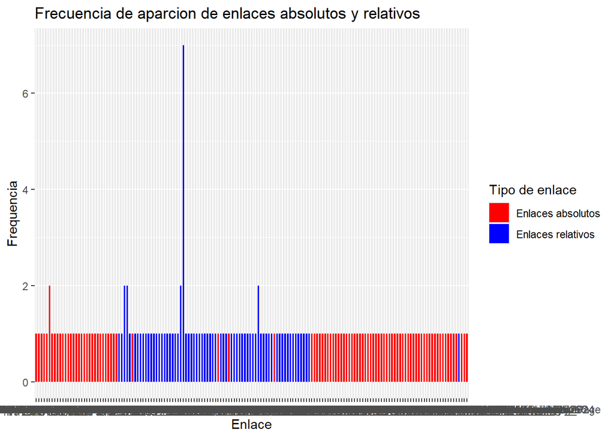

```r
ggplot() +
  geom_col(data = links_relative, aes(x = href_full, y = freq, fill = "Relative"), width = 0.6, position = "identity") +
  geom_col(data = links_absolute, aes(x = href_full, y = freq, fill = "Absolute"), width = 0.6, position = "identity") +
  labs(
    title = "Frecuencia de aparcion de enlaces absolutos y relativos",
    x = "Enlace",
    y = "Frequencia",
    fill = "Tipo de enlace"
  ) +
  scale_fill_manual(
    labels = c("Relative" = "Enlaces relativos", "Absolute" = "Enlaces absolutos"),
    values = c("Relative" = "blue", "Absolute" = "red")
  ) +
  theme(legend.position = "right")
```

**2. Un gráfico de barras indicando la suma de enlaces que apuntan a otros dominios o servicios vs. la suma de los otros enlaces.**

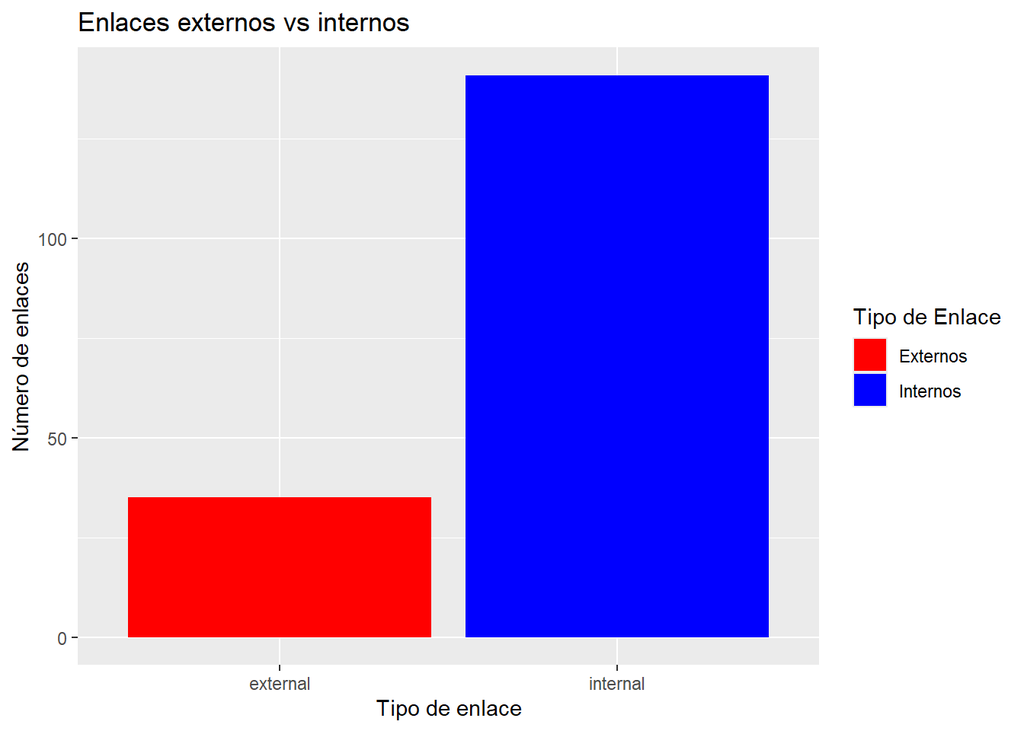

```r
ggplot(links_counts, aes(x = link_type, y = total, fill = link_type)) +
  geom_bar(stat = "identity") +
  labs(
    title = "Enlaces externos vs internos",
    x = "Tipo de enlace",
    y = "Número de enlaces"
  ) +
  scale_fill_manual(
    name   = "Tipo de Enlace",
    values = c("internal" = "blue", "external" = "red"),
    labels = c("internal" = "Internos", "external" = "Externos")
  ) +
  theme(legend.position = "right")
```

**3. Un gráfico de tarta (pie chart) indicando los porcentajes de Status de nuestro análisis.**

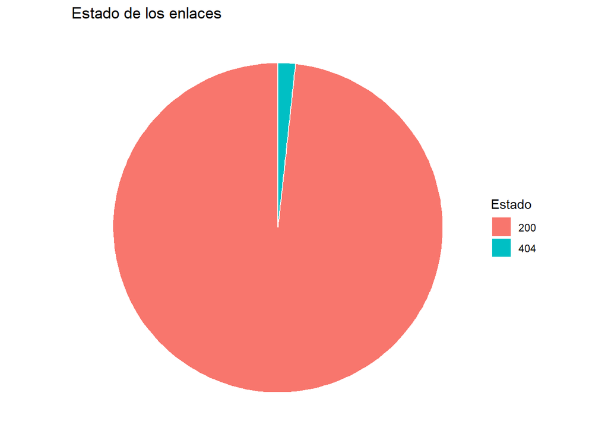

```r
ggplot(status_percentage, aes(x = "", y = total, fill = status)) +
  geom_col(width = 1, color = "white") +
  coord_polar("y", start = 0) +
  labs(
    title = "Estado de los enlaces",
    fill  = "Estado"
  ) +
  theme_void() +
  theme(legend.position = "right")
```